# Homework3

```python
#Packages
import pandas as pd
import numpy as np
```

```python
path = "/Users/serenayang/Desktop/DSC478/Homework 3"
```

## Problem 1: Linear Regression

### a. Load and preprocess the data using Pandas or Numpy and, if necessary, preprocessing functions from scikit-learn. The provided data is already normalized (see description), so there is no need for additional normalization. Compute and display basic statistics (mean, standard deviation, min, max, etc.) for each of the variables in the data set. Separate the target attribute for regression.

##### Load and preprocess the data.

```python
data = pd.read_csv(path + '/communities/communities.csv')
data.head()
```

|  | state | communityname | population | householdsize | racepctblack | racePctWhite | racePctAsian | racePctHisp | agePct12t21 | agePct12t29 | ... | NumStreet | PctForeignBorn | PctBornSameState | PctSameHouse85 | PctSameCity85 | PctSameState85 | LandArea | PopDens | PctUsePubTrans | ViolentCrimesPerPop |
| --- | --- | --- | --- | --- | --- | --- | --- | --- | --- | --- | --- | --- | --- | --- | --- | --- | --- | --- | --- | --- | --- |
| 0 | 8 | Lakewoodcity | 0.19 | 0.33 | 0.02 | 0.90 | 0.12 | 0.17 | 0.34 | 0.47 | ... | 0.0 | 0.12 | 0.42 | 0.50 | 0.51 | 0.64 | 0.12 | 0.26 | 0.20 | 0.20 |
| 1 | 53 | Tukwilacity | 0.00 | 0.16 | 0.12 | 0.74 | 0.45 | 0.07 | 0.26 | 0.59 | ... | 0.0 | 0.21 | 0.50 | 0.34 | 0.60 | 0.52 | 0.02 | 0.12 | 0.45 | 0.67 |
| 2 | 24 | Aberdeentown | 0.00 | 0.42 | 0.49 | 0.56 | 0.17 | 0.04 | 0.39 | 0.47 | ... | 0.0 | 0.14 | 0.49 | 0.54 | 0.67 | 0.56 | 0.01 | 0.21 | 0.02 | 0.43 |
| 3 | 34 | Willingborotownship | 0.04 | 0.77 | 1.00 | 0.08 | 0.12 | 0.10 | 0.51 | 0.50 | ... | 0.0 | 0.19 | 0.30 | 0.73 | 0.64 | 0.65 | 0.02 | 0.39 | 0.28 | 0.12 |
| 4 | 42 | Bethlehemtownship | 0.01 | 0.55 | 0.02 | 0.95 | 0.09 | 0.05 | 0.38 | 0.38 | ... | 0.0 | 0.11 | 0.72 | 0.64 | 0.61 | 0.53 | 0.04 | 0.09 | 0.02 | 0.03 |

5 rows × 100 columns

##### Compute and display basic statistics (mean, standard deviation, min, max, etc.) for each of the variables in the data set.

```python
data.describe()
```

|  | state | population | householdsize | racepctblack | racePctWhite | racePctAsian | racePctHisp | agePct12t21 | agePct12t29 | agePct16t24 | ... | NumStreet | PctForeignBorn | PctBornSameState | PctSameHouse85 | PctSameCity85 | PctSameState85 | LandArea | PopDens | PctUsePubTrans | ViolentCrimesPerPop |
| --- | --- | --- | --- | --- | --- | --- | --- | --- | --- | --- | --- | --- | --- | --- | --- | --- | --- | --- | --- | --- | --- |
| count | 1994.000000 | 1994.000000 | 1994.000000 | 1994.000000 | 1994.000000 | 1994.000000 | 1994.000000 | 1994.000000 | 1994.000000 | 1994.000000 | ... | 1994.000000 | 1994.000000 | 1994.000000 | 1994.000000 | 1994.000000 | 1994.000000 | 1994.000000 | 1994.000000 | 1994.000000 | 1994.000000 |
| mean | 28.683551 | 0.057593 | 0.463395 | 0.179629 | 0.753716 | 0.153681 | 0.144022 | 0.424218 | 0.493867 | 0.336264 | ... | 0.022778 | 0.215552 | 0.608892 | 0.535050 | 0.626424 | 0.651530 | 0.065231 | 0.232854 | 0.161685 | 0.237979 |
| std | 16.397553 | 0.126906 | 0.163717 | 0.253442 | 0.244039 | 0.208877 | 0.232492 | 0.155196 | 0.143564 | 0.166505 | ... | 0.100400 | 0.231134 | 0.204329 | 0.181352 | 0.200521 | 0.198221 | 0.109459 | 0.203092 | 0.229055 | 0.232985 |
| min | 1.000000 | 0.000000 | 0.000000 | 0.000000 | 0.000000 | 0.000000 | 0.000000 | 0.000000 | 0.000000 | 0.000000 | ... | 0.000000 | 0.000000 | 0.000000 | 0.000000 | 0.000000 | 0.000000 | 0.000000 | 0.000000 | 0.000000 | 0.000000 |
| 25% | 12.000000 | 0.010000 | 0.350000 | 0.020000 | 0.630000 | 0.040000 | 0.010000 | 0.340000 | 0.410000 | 0.250000 | ... | 0.000000 | 0.060000 | 0.470000 | 0.420000 | 0.520000 | 0.560000 | 0.020000 | 0.100000 | 0.020000 | 0.070000 |
| 50% | 34.000000 | 0.020000 | 0.440000 | 0.060000 | 0.850000 | 0.070000 | 0.040000 | 0.400000 | 0.480000 | 0.290000 | ... | 0.000000 | 0.130000 | 0.630000 | 0.540000 | 0.670000 | 0.700000 | 0.040000 | 0.170000 | 0.070000 | 0.150000 |
| 75% | 42.000000 | 0.050000 | 0.540000 | 0.230000 | 0.940000 | 0.170000 | 0.160000 | 0.470000 | 0.540000 | 0.360000 | ... | 0.000000 | 0.280000 | 0.777500 | 0.660000 | 0.770000 | 0.790000 | 0.070000 | 0.280000 | 0.190000 | 0.330000 |
| max | 56.000000 | 1.000000 | 1.000000 | 1.000000 | 1.000000 | 1.000000 | 1.000000 | 1.000000 | 1.000000 | 1.000000 | ... | 1.000000 | 1.000000 | 1.000000 | 1.000000 | 1.000000 | 1.000000 | 1.000000 | 1.000000 | 1.000000 | 1.000000 |

8 rows × 98 columns

```python
data.shape
```

```
(1994, 100)
```

```python
#drop na
data = data.replace({'?' : np.nan})
data = data.astype({'OtherPerCap': 'float'})
data['OtherPerCap'].fillna(data['OtherPerCap'].mean(),inplace=True)
#data = data.dropna()
data.shape
```

```
(1994, 100)
```

##### Separate the target attribute for regression.

```python
target = data.ViolentCrimesPerPop
data.drop(columns = ['ViolentCrimesPerPop', 'state', 'communityname'], axis = 1, inplace = True)
```

```python
data.shape
```

```
(1994, 97)
```

```python
target.head()
```

```
0    0.20
1    0.67
2    0.43
3    0.12
4    0.03
Name: ViolentCrimesPerPop, dtype: float64
```

```python
#check whether every variables are float
data.info()
```

```
<class 'pandas.core.frame.DataFrame'>
RangeIndex: 1994 entries, 0 to 1993
Data columns (total 97 columns):
 #   Column                 Non-Null Count  Dtype
---  ------                 --------------  -----
 0   population             1994 non-null   float64
 1   householdsize          1994 non-null   float64
 2   racepctblack           1994 non-null   float64
 3   racePctWhite           1994 non-null   float64
 4   racePctAsian           1994 non-null   float64
 5   racePctHisp            1994 non-null   float64
 6   agePct12t21            1994 non-null   float64
 7   agePct12t29            1994 non-null   float64
 8   agePct16t24            1994 non-null   float64
 9   agePct65up             1994 non-null   float64
```

[output cut: 89 more lines]

### b. Perform standard linear regression on data using the implementation for Ch. 8 of MLA. Compute the RMSE value on the full training data. Also, plot the correlation between the predicted and actual values of the target attribute. Display the obtained regression coefficients (weights). Finally, perform 10-fold cross-validation and compare the cross-validation RMSE to the training RMSE (for cross validation, you should use the KFold module from sklearn.cross_validation).

##### Perform standard linear regression on data using the implementation for Ch. 8 of MLA

```python
#Convert predictive variables (x) and target variable (y) to arrays:
x = np.array(data)
y = np.array(target)
```

```python
#Add a column of 1s for x0 in x_array:
x = np.array([np.concatenate((v,[1])) for v in x])
x
```

```
array([[0.19, 0.33, 0.02, ..., 0.26, 0.2 , 1.  ],
       [0.  , 0.16, 0.12, ..., 0.12, 0.45, 1.  ],
       [0.  , 0.42, 0.49, ..., 0.21, 0.02, 1.  ],
       ...,
       [0.16, 0.37, 0.25, ..., 0.32, 0.18, 1.  ],
       [0.08, 0.51, 0.06, ..., 0.38, 0.33, 1.  ],
       [0.2 , 0.78, 0.14, ..., 0.3 , 0.05, 1.  ]])
```

```python
#create regression function
def standRegres(xArr, yArr):
    xMat = np.matrix(xArr) ; yMat = np.matrix(yArr).T
    xTx = xMat.T*xMat
    if np.linalg.det(xTx) == 0.0:
        print("This matrix is singular, cannot do inverse")
    else:
        ws = xTx.I * (xMat.T*yMat)
        return ws
```

```python
w = standRegres(x, y)     #weights
w
```

```
matrix([[ 1.31108068e-01],
        [-3.14114977e-02],
        [ 2.09909670e-01],
        [-4.05351612e-02],
        [-1.38892919e-02],
        [ 5.89726825e-02],
        [ 1.23399025e-01],
        [-2.22621600e-01],
        [-1.47500199e-01],
        [ 5.01635477e-02],
        [-2.42413829e-01],
        [ 4.64024392e-02],
        [-1.96945615e-01],
        [-2.06117500e-01],
        [ 4.65935490e-02],
        [-1.77212915e-01],
        [ 6.30148504e-02],
        [ 1.14942190e-02],
        [-9.08951848e-02],
        [ 2.74640044e-01],
        [ 1.01752476e-01],
        [-3.31517562e-01],
        [-2.91799268e-02],
        [-3.54483393e-02],
        [ 2.26173855e-02],
        [ 4.30950137e-02],
        [ 3.44408548e-02],
        [ 1.28412458e-01],
        [-1.91293360e-01],
        [-1.00769002e-01],
        [ 6.46856092e-02],
        [ 1.06062117e-01],
        [ 2.44125963e-06],
        [ 2.34984611e-01],
        [-3.75705330e-02],
        [-7.74957660e-03],
        [ 4.66779619e-01],
        [ 2.26295907e-01],
        [ 1.74621953e-01],
        [-5.75206227e-01],
```

[output cut: 43 more lines]

```
        [ 3.74730887e-01],
        [ 4.17402525e-02],
        [-4.45747318e-02],
        [-8.34683479e-02],
        [ 1.30736305e-01],
        [ 1.83468559e-01],
        [ 1.26046949e-01],
        [ 4.63490658e-03],
        [-2.24577196e-02],
        [ 2.88627319e-02],
        [ 1.30622513e-02],
        [ 2.76170980e-02],
        [-1.24479622e-02],
        [-3.73099899e-02],
        [ 5.88079813e-01]])
```

##### Compute the RMSE value on the full training data.

```python
# sum of squared errors
yHat = x * w      # Predictions
yHatT = yHat.T

# error rate
err = abs(yHatT-y)

# Dot product of error vector with itself gives us the sum of squared errors
total_error = np.dot(err, err.T)

# compute RMSE
rmse = np.sqrt(total_error/len(yHat))
print("RMSE: ", rmse)
```

```
RMSE:  [[0.12888961]]
```

##### plot the correlation between the predicted and actual values of the target attribute

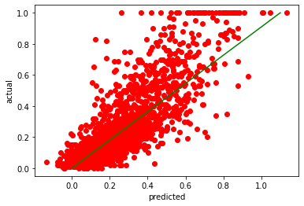

```python
import matplotlib.pyplot as plt
plt.plot(yHat, y,'ro')
plt.plot([0,1.1],[0,1], 'g-')
plt.xlabel('predicted')
plt.ylabel('actual')
plt.show()
```

##### Display the obtained regression coefficients (weights).

```python
#Create linear regression model & train the model on the full dataset using sklearn.linear_model
from sklearn.linear_model import LinearRegression, Lasso, Ridge, ElasticNet, SGDRegressor

model = LinearRegression()
model.fit(x,y)
```

```
LinearRegression()
```

```python
#the predictions for the first 10 instances:
print(model.predict(x[:10]))
```

```
[ 0.16551838  0.29062973  0.38367799  0.32270857 -0.02129155  0.23017938
  0.08800201  0.4423392   0.23747971  0.00526097]
```

```python
# Compute RMSE on training data
p = model.predict(x)

# Now we can constuct a vector of errors
errors = abs(p - y)

# Let's see the error on the first 10 predictions
print (errors[:10])
```

```
[0.03448162 0.37937027 0.04632201 0.20270857 0.05129155 0.09017938
 0.05800201 0.1076608  0.29252029 0.14473903]
```

```python
# Dot product of error vector with itself gives us the sum of squared errors
total_error = np.dot(errors,errors)

# Compute RMSE
rmse_train = np.sqrt(total_error/len(p))
print ('RMSE rounded to four decimal places: {}'.format(round(rmse_train, 4)))
```

```
RMSE rounded to four decimal places: 0.1289
```

```python
# We can view the regression coefficients
print ('Regression Coefficients: \n', model.coef_)
```

```
Regression Coefficients:
 [ 1.31108068e-01 -3.14114977e-02  2.09909670e-01 -4.05351612e-02
 -1.38892919e-02  5.89726825e-02  1.23399025e-01 -2.22621600e-01
 -1.47500199e-01  5.01635477e-02 -2.42413829e-01  4.64024392e-02
 -1.96945615e-01 -2.06117500e-01  4.65935490e-02 -1.77212915e-01
  6.30148504e-02  1.14942190e-02 -9.08951848e-02  2.74640044e-01
  1.01752476e-01 -3.31517562e-01 -2.91799268e-02 -3.54483393e-02
  2.26173855e-02  4.30950137e-02  3.44408548e-02  1.28412458e-01
 -1.91293360e-01 -1.00769002e-01  6.46856092e-02  1.06062117e-01
  2.44125996e-06  2.34984611e-01 -3.75705330e-02 -7.74957660e-03
  4.66779619e-01  2.26295907e-01  1.74621953e-01 -5.75206227e-01
 -1.41954207e-01  5.68782538e-02 -3.51066745e-01 -3.49493414e-02
  4.63705978e-04  5.57016681e-02 -1.82238360e-01 -1.54646442e-01
  1.26172899e-01 -1.44320569e-01  2.39071713e-02  3.33390229e-02
 -7.42297409e-02  3.59876412e-02 -3.31691535e-02 -2.18174916e-01
  4.45777391e-01 -2.00030978e-01 -2.67307658e-02 -1.41457254e-01
  6.38133109e-02 -2.10115806e-01  6.51276465e-01 -8.02774919e-02
 -2.53817057e-01 -6.66334925e-01  2.01002575e-01  1.03326247e-01
  2.88599766e-02  1.68314795e-01 -4.00752791e-02  5.53867355e-01
  4.70396419e-02 -7.64314747e-02 -2.89277350e-02  1.40739015e-02
 -1.40629951e-02 -3.46854609e-01  2.67796471e-01  1.19446906e-02
 -2.36996317e-01 -2.60764386e-02 -6.84041742e-02  3.74730887e-01
  4.17402525e-02 -4.45747318e-02 -8.34683479e-02  1.30736305e-01
  1.83468559e-01  1.26046949e-01  4.63490658e-03 -2.24577196e-02
  2.88627319e-02  1.30622513e-02  2.76170980e-02 -1.24479622e-02
 -3.73099899e-02  0.00000000e+00]
```

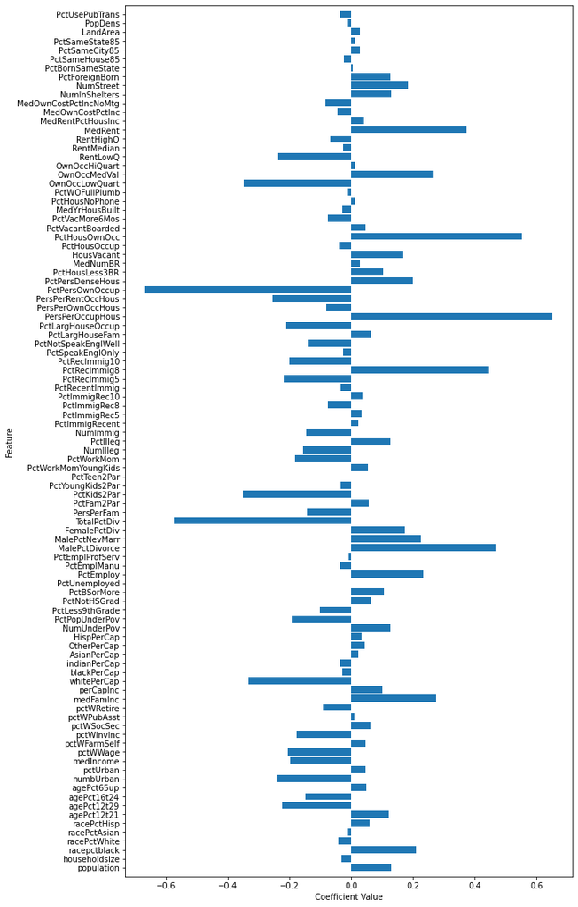

```python
def plot_coefficients(model, n_features, feature_names):
    plt.figure(figsize=(10,20))
    plt.barh(range(n_features), model.coef_[:-1], align='center')
    plt.yticks(np.arange(n_features), feature_names)
    plt.xlabel("Coefficient Value")
    plt.ylabel("Feature")
    plt.ylim(-1, n_features)

plot_coefficients(model, len(data.columns), data.columns)
```

```python
coefDIC = {}

for i in range(len(model.coef_)-1):
    coefDIC[data.columns[i]] = model.coef_[i]

coefTable = pd.DataFrame(coefDIC.items(), columns=['Features', 'Coefficient'])
coefTable
```

|  | Features | Coefficient |
| --- | --- | --- |
| 0 | population | 0.131108 |
| 1 | householdsize | -0.031411 |
| 2 | racepctblack | 0.209910 |
| 3 | racePctWhite | -0.040535 |
| 4 | racePctAsian | -0.013889 |
| ... | ... | ... |
| 92 | PctSameCity85 | 0.028863 |
| 93 | PctSameState85 | 0.013062 |
| 94 | LandArea | 0.027617 |
| 95 | PopDens | -0.012448 |
| 96 | PctUsePubTrans | -0.037310 |

97 rows × 2 columns

##### perform 10-fold cross-validation and compare the cross-validation RMSE to the training RMSE (for cross validation, you should use the KFold module from sklearn.cross_validation).

```python
from sklearn.model_selection import KFold

n = 10

kf = KFold(n_splits=n)
kf.get_n_splits(x)

xval_err = 0
for train, test in kf.split(x):
    model.fit(x[train],y[train])
    p = model.predict(x[test])
    e = p-y[test]
    xval_err += np.sqrt(np.dot(e,e)/len(x[test]))

rmse_10cv = xval_err/n
```

```python
#Compare RMSE on full training data to RMSE using 10-fold cross-validation
method_name = 'Simple Linear Regression'
print('Method: %s' %method_name)
print('RMSE on training/full dataset: %.4f' %rmse)
print('RMSE on 10-fold CV: %.4f' %rmse_10cv)
```

```
Method: Simple Linear Regression
RMSE on training/full dataset: 0.1289
RMSE on 10-fold CV: 0.1359
```

### c. Feature Selection: use the scikit-learn regression model from sklearn.linear_model with a subset of features to perform linear regression. For feature selection, write a script or function that takes as input the training data, target variable; the model; and any other parameters you find necessary, and returns the optimal percentage of the most informative features to use. Your approach should use k-fold cross-validation on the training data (you can use k=5). You can use feature_selection.SelectPercentile to find the most informative variables. Show the list of most informative variables and their weights [Note: since this is regression not classification, you should use feature_selection.f_regression as scoring function rather than chi2). Next, plot the model's mean absolute error values on cross-validation relative to the percentage of selected features (See scikit-learn's metrics.mean_absolute_error). In order to use cross_validation.cross_val_score with regression you'll need to pass to it scoring='mean_absolute_error' as a parameter. [Hint: for an example of a similar feature selection process please review the class example notebook. Also, review scikit-learn documentation for feature selection.]

```python
import warnings
warnings.filterwarnings("ignore", category=RuntimeWarning)

from sklearn.linear_model import LinearRegression
from sklearn import feature_selection
from sklearn.model_selection import cross_val_score, cross_validate
```

```python
#seprate into test and train sets
from sklearn.model_selection import train_test_split

x_train, x_test, y_train, y_test = train_test_split(x, y, test_size=0.2, random_state=33)
print(x_train.shape, y_train.shape)
```

```
(1595, 98) (1595,)
```

```python
linreg = LinearRegression()

percentiles = range(1, 101, 5)
results = []

for i in percentiles:
    fs = feature_selection.SelectPercentile(feature_selection.f_regression, percentile=i)
    X_train_fs = fs.fit_transform(x_train, y_train)
    scores = cross_val_score(linreg, X_train_fs, y_train, cv=5)
    print("%2d  %0.4f" % (i, scores.mean()))
    results = np.append(results, scores.mean())
```

```
 1  0.5497
 6  0.6095
11  0.6189
16  0.6234
21  0.6341
26  0.6491
31  0.6518
36  0.6525
41  0.6533
46  0.6518
51  0.6502
56  0.6522
61  0.6533
66  0.6540
71  0.6529
76  0.6579
81  0.6573
86  0.6578
91  0.6575
96  0.6581
```

```python
optimal_percentile = np.where(results == results.max())[0]
print(optimal_percentile[0])
print ("Optimal percentile of features: {0}%".format(percentiles[optimal_percentile[0]]), "\n")
optimal_num_features = int(percentiles[optimal_percentile[0]]*len(data.columns)/100)
print ("Optimal number of features: {0}".format(optimal_num_features), "\n")
```

```
19
Optimal percentile of features: 96%

Optimal number of features: 93
```

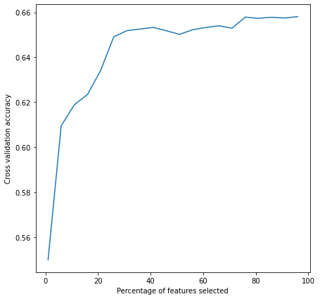

```python
# Plot percentile of features VS. cross-validation scores
import pylab as pl
pl.rcParams["figure.figsize"] = (7,7)
pl.figure()
pl.xlabel("Percentage of features selected")
pl.ylabel("Cross validation accuracy")
pl.plot(percentiles,results)
```

```python
# Use feature_selection.f_regression / not chi2(only for classification)
fs = feature_selection.SelectPercentile(feature_selection.f_regression, percentile=30)
x_train_fs = fs.fit_transform(x_train, y_train)
```

```python
scores = cross_val_score(linreg, x_train_fs, y_train, cv=5, scoring='neg_mean_absolute_error')
scores = [abs(i) for i in scores]
print("Mean Absolute Error: ", np.mean(scores))
```

```
Mean Absolute Error:  0.09478480270197638
```

```python
np.set_printoptions(suppress=True, precision=2, linewidth=80)
fs.get_support()
```

```
array([ True, False,  True,  True, False, False, False, False, False, False,
        True, False,  True, False, False,  True, False,  True, False,  True,
       False, False, False, False, False, False, False,  True,  True,  True,
        True, False,  True, False, False, False,  True, False,  True,  True,
       False,  True,  True,  True,  True, False, False,  True,  True, False,
       False, False, False, False, False, False, False, False, False, False,
       False, False, False, False, False,  True,  True,  True, False,  True,
       False,  True,  True, False, False,  True, False, False, False, False,
       False, False, False, False, False, False, False,  True, False, False,
       False, False, False, False, False, False, False, False])
```

```python
data.columns.values
```

```
array(['population', 'householdsize', 'racepctblack', 'racePctWhite',
       'racePctAsian', 'racePctHisp', 'agePct12t21', 'agePct12t29',
       'agePct16t24', 'agePct65up', 'numbUrban', 'pctUrban', 'medIncome',
       'pctWWage', 'pctWFarmSelf', 'pctWInvInc', 'pctWSocSec', 'pctWPubAsst',
       'pctWRetire', 'medFamInc', 'perCapInc', 'whitePerCap', 'blackPerCap',
       'indianPerCap', 'AsianPerCap', 'OtherPerCap', 'HispPerCap',
       'NumUnderPov', 'PctPopUnderPov', 'PctLess9thGrade', 'PctNotHSGrad',
       'PctBSorMore', 'PctUnemployed', 'PctEmploy', 'PctEmplManu',
       'PctEmplProfServ', 'MalePctDivorce', 'MalePctNevMarr', 'FemalePctDiv',
       'TotalPctDiv', 'PersPerFam', 'PctFam2Par', 'PctKids2Par',
       'PctYoungKids2Par', 'PctTeen2Par', 'PctWorkMomYoungKids', 'PctWorkMom',
       'NumIlleg', 'PctIlleg', 'NumImmig', 'PctImmigRecent', 'PctImmigRec5',
       'PctImmigRec8', 'PctImmigRec10', 'PctRecentImmig', 'PctRecImmig5',
       'PctRecImmig8', 'PctRecImmig10', 'PctSpeakEnglOnly',
       'PctNotSpeakEnglWell', 'PctLargHouseFam', 'PctLargHouseOccup',
       'PersPerOccupHous', 'PersPerOwnOccHous', 'PersPerRentOccHous',
       'PctPersOwnOccup', 'PctPersDenseHous', 'PctHousLess3BR', 'MedNumBR',
       'HousVacant', 'PctHousOccup', 'PctHousOwnOcc', 'PctVacantBoarded',
       'PctVacMore6Mos', 'MedYrHousBuilt', 'PctHousNoPhone', 'PctWOFullPlumb',
       'OwnOccLowQuart', 'OwnOccMedVal', 'OwnOccHiQuart', 'RentLowQ',
       'RentMedian', 'RentHighQ', 'MedRent', 'MedRentPctHousInc',
       'MedOwnCostPctInc', 'MedOwnCostPctIncNoMtg', 'NumInShelters',
       'NumStreet', 'PctForeignBorn', 'PctBornSameState', 'PctSameHouse85',
       'PctSameCity85', 'PctSameState85', 'LandArea', 'PopDens',
       'PctUsePubTrans'], dtype=object)
```

```python
fs.scores_
```

```
array([ 256.03,    3.49, 1074.89, 1412.51,    1.96,  137.54,    4.89,   37.33,
         15.88,    8.25,  247.78,   11.06,  341.63,  161.57,   40.34,  756.01,
         22.49,  784.57,   13.98,  366.9 ,  214.99,   65.45,  126.58,   12.32,
         29.07,   33.37,   92.37,  400.31,  578.82,  319.22,  472.2 ,  173.37,
        533.91,  190.47,    2.61,    7.4 ,  602.77,  161.08,  704.77,  693.14,
         24.47, 1657.87, 1972.8 , 1342.17, 1299.54,    1.31,   36.5 ,  431.64,
       1936.12,  151.62,   40.65,   70.23,   96.28,  134.79,   85.2 ,  101.54,
        106.97,  116.9 ,   92.38,  144.66,  241.23,  129.54,    4.35,   28.4 ,
         93.29,  630.76,  375.65,  487.96,  242.07,  339.97,  173.74,  478.53,
        507.64,    0.27,   18.64,  505.86,  209.11,   71.34,   57.98,   46.44,
        104.03,   95.72,   90.25,   95.92,  178.68,    6.72,    4.32,  265.85,
        169.53,   61.96,    9.71,   40.93,    9.17,    0.8 ,   61.98,  142.69,
         40.12,     nan])
```

```python
for i in range(len(data.columns.values)):
    if fs.get_support()[i]:
        print(data.columns.values[i],'\t', fs.scores_[i])
```

```
population 	 256.03235473721196
racepctblack 	 1074.8895092675189
racePctWhite 	 1412.507812392619
numbUrban 	 247.77613854814777
medIncome 	 341.63253752319923
pctWInvInc 	 756.0149723312607
pctWPubAsst 	 784.570640809259
medFamInc 	 366.9004218440574
NumUnderPov 	 400.30785689079477
PctPopUnderPov 	 578.8173652137622
PctLess9thGrade 	 319.21810810192477
PctNotHSGrad 	 472.19620786905864
PctUnemployed 	 533.9131521991952
MalePctDivorce 	 602.774893581593
FemalePctDiv 	 704.772739004815
TotalPctDiv 	 693.1378303821936
PctFam2Par 	 1657.8650169982209
PctKids2Par 	 1972.8040638665377
PctYoungKids2Par 	 1342.1736137876032
PctTeen2Par 	 1299.5351058426977
NumIlleg 	 431.63556026914017
PctIlleg 	 1936.120873782696
PctPersOwnOccup 	 630.7603393739731
PctPersDenseHous 	 375.6459018761208
PctHousLess3BR 	 487.96168084238917
HousVacant 	 339.9686181620906
PctHousOwnOcc 	 478.5304297184818
PctVacantBoarded 	 507.6364085419919
PctHousNoPhone 	 505.8626527468782
NumInShelters 	 265.84594187525454
```

### d. Next, perform Ridge Regression and Lasso Regression using the modules from sklearn.linear_model. In each case, perform systematic model selection to identify the optimal alpha parameter. First, create a 20%-80% randomized split of the data. Set aside the test portion; the model selection process should be performed using the 80% training data partition. You should create a function that takes as input the data and target variable; the parameter to vary and a list of its values; the model to be trained; and any other relevant input needed to determine the optimal value for the specified parameter. The model selection process should perform k-fold cross validation (k should be a parameter, but you can select k=5 for this problem). You should also plot the error values on the training and cross-validation splits across the specified values of the alpha parameter. Finally, using the best alpha value, run the model on the set-aside test data. Discuss your observation and conclusions. [Hint: for an example of a similar model selection process please review the class example notebook.]

```python
from sklearn.linear_model import Lasso, Ridge
from sklearn import model_selection
from sklearn.metrics import mean_absolute_error
```

##### First, create a 20%-80% randomized split of the data. Set aside the test portion; the model selection process should be performed using the 80% training data partition.

```python
# Creating 20-80 randomized split of the data
from sklearn.model_selection import train_test_split
x_train, x_test, y_train, y_test = train_test_split(x, y, test_size=0.2, random_state = 33)
x_test.size
```

```
39102
```

```python
x_train.size
```

```
156310
```

##### You should create a function that takes as input the data and target variable; the parameter to vary and a list of its values; the model to be trained; and any other relevant input needed to determine the optimal value for the specified parameter.

```python
#systematic model selection
from sklearn.model_selection import KFold

def calc_params(X, y, clf, param_values, param_name, K):

    # Convert input to Numpy arrays
    X = np.array(X)
    y = np.array(y)

    # initialize training and testing score arrays with zeros
    train_scores = np.zeros(len(param_values))
    test_scores = np.zeros(len(param_values))

    # iterate over the different parameter values
    for i, param_value in enumerate(param_values):

        # set classifier parameters
        clf.set_params(**{param_name:param_value})

        # initialize the K scores obtained for each fold
        k_train_scores = np.zeros(K)
        k_test_scores = np.zeros(K)

        # create KFold cross validation
        cv = KFold(n_splits=K, shuffle=True, random_state=0)

        # iterate over the K folds

        for j, (train, test) in enumerate(cv.split(X)):
            # fit the classifier in the corresponding fold
            # and obtain the corresponding accuracy scores on train and test sets
            clf.fit(X[train], y[train])
            k_train_scores[j] = clf.score(X[train], y[train])
            k_test_scores[j] = clf.score(X[test], y[test])


        # store the mean of the K fold scores
        train_scores[i] = np.mean(k_train_scores)
        test_scores[i] = np.mean(k_test_scores)
        print('{}: {} \t\t\t training scores: {}'.format(param_name, param_value,train_scores[i]))

    # plot the training and testing scores in a log scale
    plt.plot(param_values, train_scores, label='Train', alpha=0.4, lw=2, c='b')
    plt.plot(param_values, test_scores, label='X-Val', alpha=0.4, lw=2, c='g')
    plt.legend(loc=7)
    plt.xlabel(param_name + " values")
    plt.ylabel("Mean cross validation accuracy")

    # return the training and testing scores on each parameter value
    return train_scores, test_scores
```

#### Ridge Regression

##### The model selection process should perform k-fold cross validation (k should be a parameter, but you can select k=5 for this problem). You should also plot the error values on the training and cross-validation splits across the specified values of the alpha parameter.

```
alpha: 0.01 			 training scores: 0.7067708460065149
alpha: 0.41795918367346935 			 training scores: 0.7026971835517688
alpha: 0.8259183673469387 			 training scores: 0.7001068716977865
alpha: 1.233877551020408 			 training scores: 0.69809299235483
alpha: 1.6418367346938774 			 training scores: 0.6964160512268281
alpha: 2.0497959183673466 			 training scores: 0.694969557782508
alpha: 2.457755102040816 			 training scores: 0.6936936993828453
alpha: 2.865714285714285 			 training scores: 0.6925504525846071
alpha: 3.2736734693877545 			 training scores: 0.6915137276610258
alpha: 3.681632653061224 			 training scores: 0.6905646687535472
alpha: 4.0895918367346935 			 training scores: 0.6896891222939213
alpha: 4.497551020408163 			 training scores: 0.6888761516834029
alpha: 4.905510204081632 			 training scores: 0.6881171090170748
alpha: 5.313469387755101 			 training scores: 0.6874050260445221
alpha: 5.721428571428571 			 training scores: 0.6867341988302499
alpha: 6.12938775510204 			 training scores: 0.68609989542773
alpha: 6.537346938775509 			 training scores: 0.685498144648033
alpha: 6.9453061224489785 			 training scores: 0.6849255799820144
alpha: 7.353265306122448 			 training scores: 0.6843793220398429
alpha: 7.761224489795917 			 training scores: 0.6838568885101839
alpha: 8.169183673469387 			 training scores: 0.6833561241759799
alpha: 8.577142857142857 			 training scores: 0.6828751458054313
alpha: 8.985102040816326 			 training scores: 0.6824122982477926
alpha: 9.393061224489795 			 training scores: 0.6819661190871033
alpha: 9.801020408163264 			 training scores: 0.6815353099143076
alpha: 10.208979591836734 			 training scores: 0.6811187127759288
alpha: 10.616938775510203 			 training scores: 0.6807152907133942
alpha: 11.024897959183672 			 training scores: 0.6803241115654032
alpha: 11.432857142857141 			 training scores: 0.6799443343957158
alpha: 11.84081632653061 			 training scores: 0.6795751980501886
alpha: 12.24877551020408 			 training scores: 0.6792160114533952
alpha: 12.65673469387755 			 training scores: 0.6788661453362049
alpha: 13.064693877551019 			 training scores: 0.6785250251479438
alpha: 13.472653061224488 			 training scores: 0.6781921249550102
alpha: 13.880612244897957 			 training scores: 0.6778669621655204
alpha: 14.288571428571426 			 training scores: 0.6775490929492574
alpha: 14.696530612244896 			 training scores: 0.6772381082457525
alpha: 15.104489795918365 			 training scores: 0.6769336302721454
alpha: 15.512448979591834 			 training scores: 0.6766353094575928
alpha: 15.920408163265304 			 training scores: 0.6763428217432246
alpha: 16.328367346938776 			 training scores: 0.6760558661965945
alpha: 16.736326530612246 			 training scores: 0.6757741628977051
alpha: 17.144285714285715 			 training scores: 0.6754974510603671
alpha: 17.552244897959184 			 training scores: 0.6752254873581759
alpha: 17.960204081632654 			 training scores: 0.6749580444289622
alpha: 18.368163265306123 			 training scores: 0.6746949095353891
alpha: 18.776122448979592 			 training scores: 0.6744358833625597
alpha: 19.18408163265306 			 training scores: 0.6741807789361778
alpha: 19.59204081632653 			 training scores: 0.673929420647063
alpha: 20.0 			 training scores: 0.6736816433697375
```

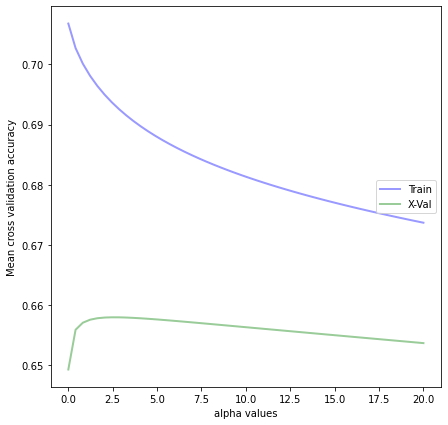

```python
# Ridge regression
alpha = np.linspace(.01,20,50)
ridge = Ridge()

train_scores, test_scores = calc_params(x_train, y_train, ridge, alpha, 'alpha', 5)
```

```python
# Need to get best value from both test and training scores
print(np.argmax(test_scores))
print(np.argmax(train_scores))
```

```
6
0
```

##### Finally, using the best alpha value, run the model on the set-aside test data.

```python
# Create linear regression object with 6 because it is not too big to cause overfitting
ridge = Ridge(alpha=alpha[6])

# Train the model with the training set
ridge.fit(x_train, y_train)

# Computing RMSE on testing data
p = ridge.predict(x_test)
error = p - y_test
total_error = np.dot(error, error)
rmse = np.sqrt(total_error/len(p))

print('Ridge Regression RMSE: ',rmse)
```

```
Ridge Regression RMSE:  0.14393057831153733
```